# Starcraft Skill Data - Exploration

Multinomial Regression Model Selection

Sergei Dakov

2023-07-20

# Preparation

First, load in required packages:

```r
library(tidyverse)
library(rsample)
library(parsnip)
library(recipes)
library(themis)
library(glmnet)
library(tune)
library(yardstick)
```

Next, load in some helper functions:

```r
source("model_selection_skeleton.r")
```

Finally, we load in the data, some of the data has missing values so we drop these columns (since the logistic regression model cannot handle those):

```r
skillData <- read_csv("SkillCraft1_Dataset.csv") %>% select(-c('GameID','TotalHours','Age','HoursPerWeek')) %>% mutate(LeagueIndex = factor(LeagueIndex))
```

Split the data to produce a validation set:

```r
set.seed(1234)
reg_split <- initial_split(skillData,strata = "LeagueIndex")
regression_train <- training(reg_split)
regression_test <- testing(reg_split)
```

Define the model to be used as baseline for the multinomial regression setting, and perform the initial split:

```r
mod_multi <- multinom_reg(mode="classification",penalty = 0.01,engine = "glmnet")

fit_multi <- mod_multi %>% fit(LeagueIndex~.,data=regression_train)
```

```r
predicted_guess <- predict(fit_multi,regression_test) %>% pull(.pred_class) #%>% as.numeric(.) %>% round(.)
```

Let’s look at the AUC and accuracy for the initial prediction

```r
comp_trial <- cbind.data.frame(truth = regression_test$LeagueIndex,prediction = predicted_guess)
comp_trial <- comp_trial %>% mutate(match = truth==prediction)
mean(comp_trial$match)
```

```
## [1] 0.4230317
```

```r
OnevRest(comp_trial,"truth","prediction")
```

```
## [1] 0.6252136
```

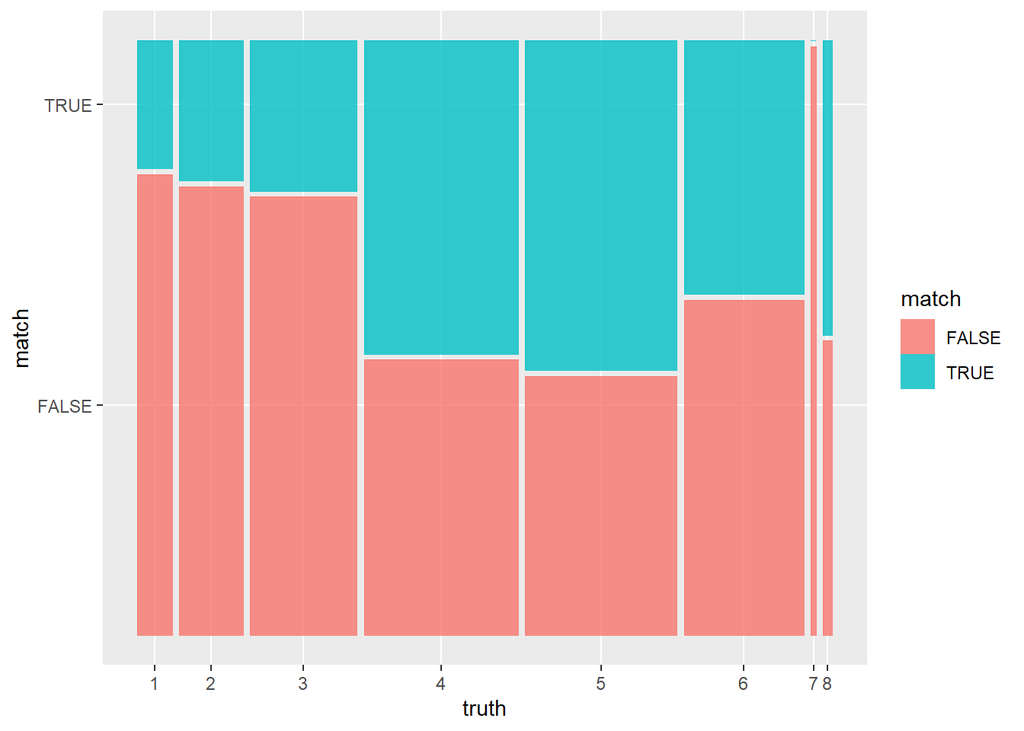

```r
library(ggplot2)
library(ggmosaic)
comp_trial %>% ggplot() + geom_mosaic(aes(x=product(match,truth),fill=match))
```

For the AUC, the result for this model is 0.625, meaning the model struggles somewhat distinguishing between classes. The accuracy is 0.423, which while not very high is at least an improvement over the naive predictions.

# Model Optimization

To test the validity of the arbitrary decisions made in the benchmark model, we load in the data again (since one of those arbitrary decisions was dropping some columns).

```r
skillData <- read_csv("SkillCraft1_Dataset.csv") %>% mutate(LeagueIndex = factor(LeagueIndex)) %>% select(-Age) %>% mutate(across(c("HoursPerWeek","TotalHours"),~as.numeric(.x)))
glimpse(skillData)
```

```
## Rows: 3,395
## Columns: 19
## $ GameID               <dbl> 52, 55, 56, 57, 58, 60, 61, 72, 77, 81, 83, 93, 9…
## $ LeagueIndex          <fct> 5, 5, 4, 3, 3, 2, 1, 7, 4, 4, 3, 4, 3, 3, 5, 5, 4…
## $ HoursPerWeek         <dbl> 10, 10, 10, 20, 10, 6, 8, 42, 14, 24, 16, 4, 12, …
## $ TotalHours           <dbl> 3000, 5000, 200, 400, 500, 70, 240, 10000, 2708, …
## $ APM                  <dbl> 143.7180, 129.2322, 69.9612, 107.6016, 122.8908, …
## $ SelectByHotkeys      <dbl> 0.0035151591, 0.0033038124, 0.0011010906, 0.00103…
## $ AssignToHotkeys      <dbl> 2.196974e-04, 2.594617e-04, 3.355705e-04, 2.13101…
## $ UniqueHotkeys        <dbl> 7, 4, 4, 1, 2, 2, 6, 6, 2, 8, 4, 3, 1, 2, 2, 4, 1…
## $ MinimapAttacks       <dbl> 1.098487e-04, 2.940566e-04, 2.936242e-04, 5.32753…
## $ MinimapRightClicks   <dbl> 3.923169e-04, 4.324362e-04, 4.614094e-04, 5.43408…
## $ NumberOfPACs         <dbl> 0.004849036, 0.004307064, 0.002925755, 0.00378255…
## $ GapBetweenPACs       <dbl> 32.6677, 32.9194, 44.6475, 29.2203, 22.6885, 76.4…
## $ ActionLatency        <dbl> 40.8673, 42.3454, 75.3548, 53.7352, 62.0813, 98.7…
## $ ActionsInPAC         <dbl> 4.7508, 4.8434, 4.0430, 4.9155, 9.3740, 3.0965, 4…
## $ TotalMapExplored     <dbl> 28, 22, 22, 19, 15, 16, 15, 45, 29, 27, 24, 19, 1…
## $ WorkersMade          <dbl> 0.00139660, 0.00119350, 0.00074455, 0.00042620, 0…
## $ UniqueUnitsMade      <dbl> 6, 5, 6, 7, 4, 6, 5, 9, 7, 6, 7, 7, 7, 5, 7, 6, 6…
## $ ComplexUnitsMade     <dbl> 0.000000e+00, 0.000000e+00, 0.000000e+00, 0.00000…
## $ ComplexAbilitiesUsed <dbl> 0.0000e+00, 2.0757e-04, 1.8876e-04, 3.8358e-04, 1…
```

We can see the data has some missing values, and is quite unbalanced.

These are things we will need to account for in model selection.

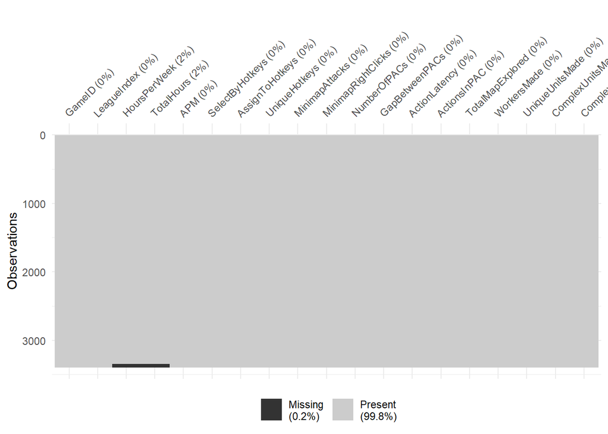

```r
library(naniar)
vis_miss(skillData)
```

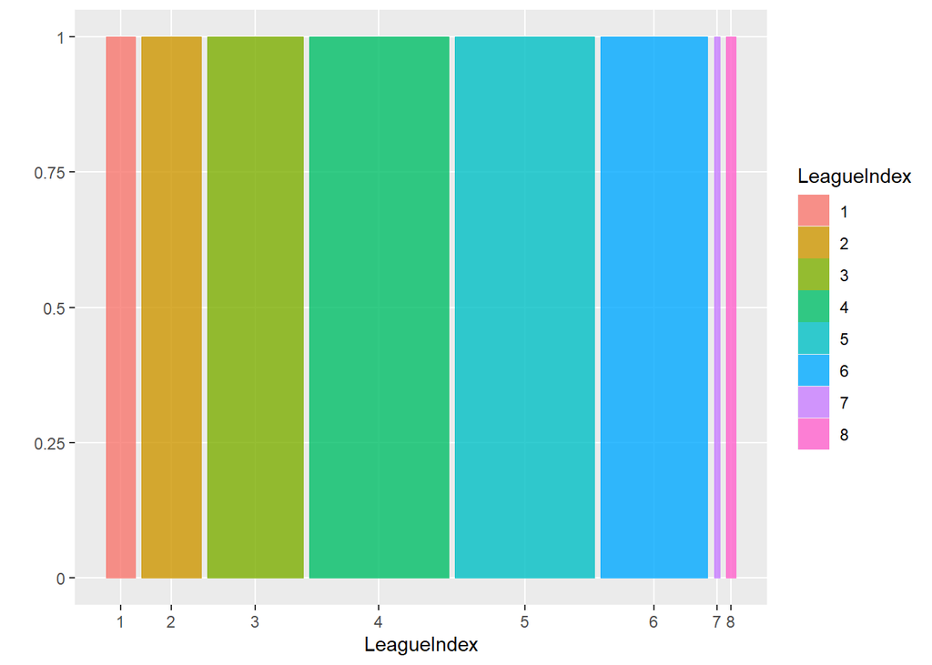

```r
skillData %>% ggplot() + geom_mosaic(aes(x=product(LeagueIndex),fill=LeagueIndex))
```

Perform the initial split again, we maintain the same seed so this split is identical to the previous one. This ensures the comparison is as fair as possible.

```r
set.seed(1234)
reg_split <- initial_split(skillData,strata = "LeagueIndex")
regression_train <- training(reg_split)
regression_test <- testing(reg_split)
```

Conveniently all the data is numeric, so the main steps of model optimization are:

- dealing with NA
- rebalancing the data
- interactions
- tuning

Dealing with interactions might require the most data points, while tuning is less significant.

Missing values are somewhat rare but might have a significant effect (exploration of the data reveals most missing data comes from one specific class)

```r
split_sizes <- c("imbalance"=600,"interactions"=800,"tuning"=500,"missing"=645)


set.seed(1234)
miss_split <- initial_split(regression_train,strata = "LeagueIndex",prop = (split_sizes["missing"]+2)/nrow(regression_train))
train_missing <- training(miss_split)
rest_split <- testing(miss_split)

set.seed(1234)
interaction_split <- initial_split(rest_split,strata="LeagueIndex",prop = ((split_sizes["interactions"])/nrow(rest_split)))
train_interaction <- training(interaction_split)
rest_split <- testing(interaction_split)

set.seed(1234)
imbalance_split <- initial_split(rest_split,strata="LeagueIndex",prop = ((split_sizes["imbalance"]+1)/nrow(rest_split)))
train_imbalance <- training(imbalance_split)
train_tuning <- testing(imbalance_split)
```